# Alejandro’s Notes

#Chapter 1. Data Visualization with ggplot2 install.packages(“tidyverse”) library(tidyverse)

mpg view(mpg)

?mpg

ggplot(data = mpg)

ggplot(data = mpg) + geom_point(mapping = aes(x = displ, y = hwy))

#A graphing template 3.2.3 ggplot(data = ) + (mapping = aes())

#3.2.4 Exercises. #Run ggplot(data = mpg). What do you see? –> A great template ggplot(data = mpg)

#How many rows are in mpg? How many columns? –> 234 x 11 mpg

#How many rows are in mtcars? How many columns? –> 32 x 11 mtcars nrow(mtcars) ncol(mtcars)

#What does the drv variable describe? Read the help for ?mpg to find out.–> f = front-wheel drive, r = rear wheel drive, 4 = 4wd ?mpg

#Make a scatterplot of hwy vs cyl. ggplot(data = mpg) + geom_point(mapping = aes(x = cyl, y = hwy))

#What happens if you make a scatterplot of class vs drv? Why is the plot not useful? –> There is no relationship between these two factor variables. It is not useful. ggplot(data = mpg) + geom_point(mapping = aes(x = class, y = drv))

#Plot using a different Dataset. ggplot(data = StateDat) + geom_point(mapping = aes(x = state, y = pctsamepty))

#Aesthetic Mapping!!!! ggplot(data = mpg) + geom_point(mapping= aes(x = displ, y = hwy, color = class))

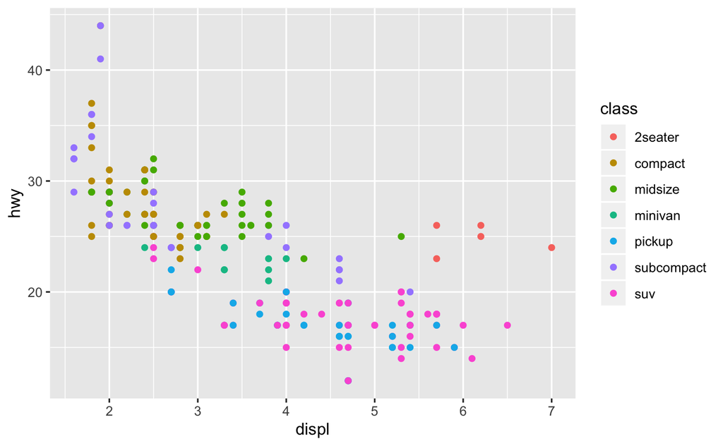

```r
ggplot(data = mpg) + geom_point(mapping = aes(x = displ, y = hwy, color = class))
```

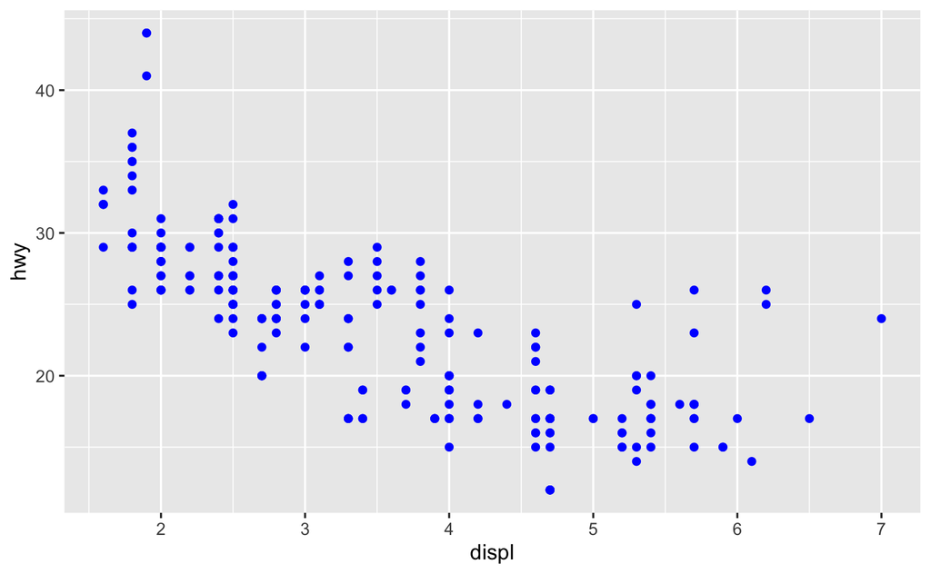

```r
ggplot(data = mpg) + geom_point(mapping = aes(x = displ, y = hwy), color = "blue")
```

## ////////////////////////////////////////////////////////////////////////////////////////////////////////////////////////////////////////////////////////////////////////////////////

Description: This notebook file was created by A. Trelles on 12/3/19 as part of the Strategy Paper.

General Description of the Data: The data file “RulingPartyLong.df” was created by A. Trelles on 12/3/19 and it is available on https://docs.google.com/spreadsheets/d/1oV81og-SVMv8IMtqflahr_ljbK4h_rCdTFTLnlIU7_E/edit?usp=sharing on a wide format. The spreadsheet contains the ruling party (governorship) at the state level for the time period 1990-2019 in five year intervals and includes the year a federal redistricting process took place (1996, 2004, 2013, and 2017). The data source is https://www.worldstatesmen.org/Mexico_states.htm.

Objectives: i. create a notebook in R studio to read an original data file that has been transformed from wide into a long format using Stata, ii. read the file located in the data environment for the project StrategyPaperAnalysis, iii. register data manipulation, iv. transorm the data intro a longitudinal/time series format (state, year, and party), v. create different measures of party presence/dominance at the state level, and vi. create some descriptive statistics using the information.

```r
help(package="dplyr")
```

Read ruling party file

```r
library(haven)
RulingParty <- read_dta("RulingPartyLong.dta")
View(RulingParty)
```

//////////////////////////////////////////////////////////////////////////////////////////Fianl Code From RulingPartyFV.R //////////////////////////////////////////////////////////////////////////////////////////

library(haven) RulingParty <- read_dta(“RulingPartyLong.dta”)

#create empty output tempout <- data.frame(state=NA, year=NA, party=NA, sameparty=NA, pctsamepty=NA, single_pty_dom_90_19=NA, single_pty_dom_00_17=NA, alt_power1_90_19 = NA, alt_power1_00_17=NA, alt_power2_90_19 = NA, alt_power2_00_17=NA,alt_power3_90_19 = NA, alt_power3_00_17=NA, primary_pol_force_90_19 = NA, primary_pol_force_00_15 = NA, secondary_pol_force_90_19 = NA, secondary_pol_force_00_15 = NA, tertiary_pol_force_90_19 = NA, tertiary_pol_force_00_15 = NA, multi_comp_90_19 = NA, multi_comp_00_17 = NA)

#Run for loop for(i in unique(RulingParty$state)){ temp <- subset(RulingParty, RulingParty$state == i) temp <- temp[order(temp$year, decreasing=F),]

temp$sameparty <- NA

#check if same party in power as prior year: for(u in 2:nrow(temp)){ temp[u,4] <- ifelse(temp[u,3]==temp[u-1,3], TRUE, FALSE) }

#percentage of years in which same party as year b4 ruled temp$pctsamepty <- ifelse(length(unique(temp$sameparty))==2,1,prop.table(table(temp$sameparty))[[2]])

#get table of ruling parties tbl <- data.frame(table(temp$party)) #get table of number of party switches tbl2 <- data.frame(table(temp$sameparty))

#PARTY DOMINANCE: #1990-2019: #single party dominance (dummy - T/F - if single party ruled) temp$single_pty_dom_90_19 <- ifelse(nrow(tbl)==1, T, F)

#IF single party did not dominate period if(temp$single_pty_dom_90_19 == F){ #alternation in power x1 (dummy - T/F - if alternation took place 1+ times) temp$alt_power1_90_19 <- ifelse(tbl2[1,2]>=1, T, F) #alternation in power x2 (dummy - T/F - if alternation took place 2+ times) temp$alt_power2_90_19 <- ifelse(tbl2[1,2]>=2, T, F) #alternation in power x3 (dummy - T/F - if alternation took place 3+ times) temp$alt_power3_90_19 <- ifelse(tbl2[1,2]>=3, T, F)

#IF single party did dominate period }else{ #alternation in power x1 (dummy - T/F - if alternation took place 1+ times) temp$alt_power1_90_19 <- F #alternation in power x2 (dummy - T/F - if alternation took place 2+ times) temp$alt_power2_90_19 <- F #alternation in power x3 (dummy - T/F - if alternation took place 3+ times) temp$alt_power3_90_19 <- F }

#2000-2017: #subset temp2 <- subset(temp, temp$year >= 2000 & temp$year <= 2017) #get table of ruling parties tbl <- data.frame(table(temp2$party)) #get table of number of party switches tbl2 <- data.frame(table(temp2$sameparty))

#single party dominance (dummy - T/F - if single party ruled) temp$single_pty_dom_00_17 <- ifelse(nrow(tbl)==1, T, F)

#IF single party did not dominate period if(temp$single_pty_dom_00_17 == F){ #alternation in power x1 (dummy - T/F - if alternation took place 1+ times) temp$alt_power1_00_17 <- ifelse(tbl2[1,2]>=1, T, F) #alternation in power x2 (dummy - T/F - if alternation took place 2+ times) temp$alt_power2_00_17 <- ifelse(tbl2[1,2]>=2, T, F) #alternation in power x3 (dummy - T/F - if alternation took place 3+ times) temp$alt_power3_00_17 <- ifelse(tbl2[1,2]>=3, T, F)

[output not shown]

}else{ #alternation in power x1 (dummy - T/F - if alternation took place 1+ times) temp$alt_power1_00_17 <- F #alternation in power x2 (dummy - T/F - if alternation took place 2+ times) temp$alt_power2_00_17 <- F #alternation in power x3 (dummy - T/F - if alternation took place 3+ times) temp$alt_power3_00_17 <- F }

#PRIMARY POLITICAL FORCE #1990-2019 temp3 <- subset(temp, !temp$year %in% c(1996,2004,2013,2017))

#table of ruling parties ptbl <- data.frame(table(temp3$party)) ptbl <- ptbl[order(ptbl$Freq, decreasing=T),]

#states with single ruling party: if(nrow(ptbl)==1){ temp$primary_pol_force_90_19 <- ptbl[1,1] temp$secondary_pol_force_90_19 <- NA temp$tertiary_pol_force_90_19 <- NA } #states with two parties if(nrow(ptbl)==2){ temp$primary_pol_force_90_19 <- ptbl[1,1] temp$secondary_pol_force_90_19 <- ptbl[2,1] temp$tertiary_pol_force_90_19 <- NA } #states with three parties if(nrow(ptbl)>=3){ temp$primary_pol_force_90_19 <- ptbl[1,1] temp$secondary_pol_force_90_19 <- ptbl[2,1] temp$tertiary_pol_force_90_19 <- ptbl[3,1] }

#2000-2015 temp4 <- subset(temp, temp$year >=2000 & temp$year <=2015 & !temp$year %in% c(1996,2004,2013,2017))

#table of ruling parties ptbl <- data.frame(table(temp4$party)) ptbl <- ptbl[order(ptbl$Freq, decreasing=T),]

#states with single ruling party: if(nrow(ptbl)==1){ temp$primary_pol_force_00_15 <- ptbl[1,1] temp$secondary_pol_force_00_15 <- NA temp$tertiary_pol_force_00_15 <- NA } #states with two parties if(nrow(ptbl)==2){ temp$primary_pol_force_00_15 <- ptbl[1,1] temp$secondary_pol_force_00_15 <- ptbl[2,1] temp$tertiary_pol_force_00_15 <- NA } #states with three parties if(nrow(ptbl)>=3){ temp$primary_pol_force_00_15 <- ptbl[1,1] temp$secondary_pol_force_00_15 <- ptbl[2,1] temp$tertiary_pol_force_00_15 <- ptbl[3,1] }

#multiparty competition? #1990-2019 temp$multi_comp_90_19 <- ifelse(is.na(temp$tertiary_pol_force_90_19), F, T) #2000-2015 temp$multi_comp_00_17 <- ifelse(is.na(temp$tertiary_pol_force_00_15), F, T)

#reorder temp column names to match tempout columns names temp <- temp[,c(1:6,10,7,11,8,12,9,13,14,17,15,18,16,19:21)] #table(names(temp)==names(tempout)) #check to make sure they match

#bind to output tempout <- rbind(temp, tempout) }

#remove empty row from original tempout file tempout <- subset(tempout, !is.na(tempout$state))

#MERGE INTO ORIGINAL DATAFRAME RulingParty$id <- paste0(RulingParty$state, RulingParty$year) #create unique identifiers for merge with new data tempout$id <- paste0(tempout$state,tempout$year) tempout <- tempout[,4:ncol(tempout)] #remove columns that are duplicated in RulingParty before merging